# Project Description:

A project from Cement manufacturing domain.

# Context:

Concrete is the most important material in civil engineering. The concrete compressive strength is a highly nonlinear function of age and ingredients. These ingredients include cement, blast furnace slag, fly ash, water, superplasticizer, coarse aggregate and fine aggregate.

# Data Description:

The actual concrete compressive strength (MPa) for a given mixture under a specific age (days) was determined from laboratory. Data is in raw form (not scaled). The data has 8 quantitative input variables, and 1 quantitative output variable, and 1030 instances (observations).

- **Input Variables:**

**Cement** : measured in kg in a m3 mixture

**Blast** : measured in kg in a m3 mixture

**Fly ash** : measured in kg in a m3 mixture

**Water** : measured in kg in a m3 mixture

**Superplasticizer** : measured in kg in a m3 mixture

**Coarse Aggregate** : measured in kg in a m3 mixture

**Fine Aggregate** : measured in kg in a m3 mixture

**Age** : day (1~365)

- **Output Variables:**

**Concrete compressive strength** : measured in MPa

# Objective:

Modeling of strength of high performance concrete using Machine Learning

### Import necessary libraries

```python
import warnings
warnings.filterwarnings('ignore')
```

```python
import numpy as np
import pandas as pd
import seaborn as sns
import matplotlib.pyplot as plt
from pprint import pprint

import xgboost
from sklearn.preprocessing import StandardScaler
from sklearn.model_selection import train_test_split
from sklearn.inspection import permutation_importance
from sklearn.linear_model import LinearRegression, Ridge, Lasso
from sklearn.preprocessing import PolynomialFeatures
from sklearn.neighbors import KNeighborsRegressor
from sklearn.tree import DecisionTreeRegressor
from sklearn.ensemble import (RandomForestRegressor, GradientBoostingRegressor, AdaBoostRegressor, BaggingRegressor)
from sklearn.svm import SVR
from mlxtend.regressor import StackingRegressor

from sklearn import metrics
from scipy import stats
from scipy.stats import zscore
from sklearn.metrics import mean_squared_error,mean_absolute_error,r2_score
from sklearn.model_selection import RandomizedSearchCV
from sklearn import preprocessing
from sklearn import tree
from sklearn.cluster import KMeans
from sklearn.utils import resample
```

```python
concrete_data = pd.read_csv('concrete.csv')
```

#### First five entries of the dataset

```python
concrete_data.head()
```

|  | cement | slag | ash | water | superplastic | coarseagg | fineagg | age | strength |
| --- | --- | --- | --- | --- | --- | --- | --- | --- | --- |
| 0 | 141.3 | 212.0 | 0.0 | 203.5 | 0.0 | 971.8 | 748.5 | 28 | 29.89 |
| 1 | 168.9 | 42.2 | 124.3 | 158.3 | 10.8 | 1080.8 | 796.2 | 14 | 23.51 |
| 2 | 250.0 | 0.0 | 95.7 | 187.4 | 5.5 | 956.9 | 861.2 | 28 | 29.22 |
| 3 | 266.0 | 114.0 | 0.0 | 228.0 | 0.0 | 932.0 | 670.0 | 28 | 45.85 |
| 4 | 154.8 | 183.4 | 0.0 | 193.3 | 9.1 | 1047.4 | 696.7 | 28 | 18.29 |

- It shows that there are eight independent variables (**cement**, **slag**, **ash**, **water**, **superplastic**, **coarseagg**, **fineagg** and **age**) and one dependent variable (**strength**).
- All the records are numeric.

## Exploratory data quality report

### Univariate Analysis

```python
concrete_data.shape
```

```
(1030, 9)
```

#### Dataframe of each attribute

```python
concrete_data.info()
```

```
<class 'pandas.core.frame.DataFrame'>
RangeIndex: 1030 entries, 0 to 1029
Data columns (total 9 columns):
 #   Column        Non-Null Count  Dtype
---  ------        --------------  -----
 0   cement        1030 non-null   float64
 1   slag          1030 non-null   float64
 2   ash           1030 non-null   float64
 3   water         1030 non-null   float64
 4   superplastic  1030 non-null   float64
 5   coarseagg     1030 non-null   float64
 6   fineagg       1030 non-null   float64
 7   age           1030 non-null   int64
 8   strength      1030 non-null   float64
dtypes: float64(8), int64(1)
memory usage: 72.5 KB
```

All the attributes apart from **age** contains floating values, whereas **age** contains integer values.

#### 5 point summary of the numerical attributes

```python
concrete_data.describe().T
```

|  | count | mean | std | min | 25% | 50% | 75% | max |
| --- | --- | --- | --- | --- | --- | --- | --- | --- |
| cement | 1030.0 | 281.167864 | 104.506364 | 102.00 | 192.375 | 272.900 | 350.000 | 540.0 |
| slag | 1030.0 | 73.895825 | 86.279342 | 0.00 | 0.000 | 22.000 | 142.950 | 359.4 |
| ash | 1030.0 | 54.188350 | 63.997004 | 0.00 | 0.000 | 0.000 | 118.300 | 200.1 |
| water | 1030.0 | 181.567282 | 21.354219 | 121.80 | 164.900 | 185.000 | 192.000 | 247.0 |
| superplastic | 1030.0 | 6.204660 | 5.973841 | 0.00 | 0.000 | 6.400 | 10.200 | 32.2 |
| coarseagg | 1030.0 | 972.918932 | 77.753954 | 801.00 | 932.000 | 968.000 | 1029.400 | 1145.0 |
| fineagg | 1030.0 | 773.580485 | 80.175980 | 594.00 | 730.950 | 779.500 | 824.000 | 992.6 |
| age | 1030.0 | 45.662136 | 63.169912 | 1.00 | 7.000 | 28.000 | 56.000 | 365.0 |
| strength | 1030.0 | 35.817961 | 16.705742 | 2.33 | 23.710 | 34.445 | 46.135 | 82.6 |

## Description of independent attributes

### Cement

##### - Range of values observed

```python
print("The value for cement ranges from", concrete_data['cement'].min() , "to", concrete_data['cement'].max(), "thus having a range of", (concrete_data['cement'].max() - concrete_data['cement'].min()) )
```

```
The value for cement ranges from 102.0 to 540.0 thus having a range of 438.0
```

##### - Central Values

```python
print("Mean of the values in cement is:", round(concrete_data['cement'].mean(), 2))
print("Median of the values in cement is:", round(concrete_data['cement'].median(), 2))
```

```
Mean of the values in cement is: 281.17
Median of the values in cement is: 272.9
```

##### - Standard Deviation

```python
print("The observations in cement deviates from mean by:", round(concrete_data['cement'].std(), 2))
```

```
The observations in cement deviates from mean by: 104.51
```

##### - Quartiles

```python
cement_25 = np.percentile(concrete_data['cement'], 25)
cement_75 = np.percentile(concrete_data['cement'], 75)
iqr_cement = cement_75 - cement_25

print("The first quartile Q1 is:", cement_25)
print("The third quartile Q3 is:", cement_75)
print("The interquartile range IQR is:", iqr_cement)
```

```
The first quartile Q1 is: 192.375
The third quartile Q3 is: 350.0
The interquartile range IQR is: 157.625
```

##### - Outliers Detection

```
The number of outliers in 'cement' out off 1030 records are: 0
```

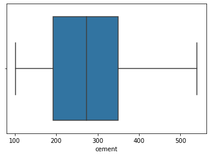

```python
cutoff_cement = 1.5 * iqr_cement
low_lim_cement = cement_25 - cutoff_cement
upp_lim_cement = cement_75 + cutoff_cement

outlier_cement = [x for x in concrete_data['cement'] if x < low_lim_cement or x > upp_lim_cement]
print("The number of outliers in 'cement' out off 1030 records are:", len(outlier_cement))

#plotting of 'cement':
sns.boxplot(concrete_data['cement'])
```

##### - Data Distribution in Cement

```
The skewness in the data is: 0.5094811788717731
```

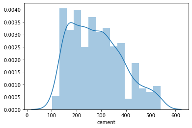

```python
sns.distplot(concrete_data['cement'], kde = True)
print("The skewness in the data is:", concrete_data['cement'].skew())
```

##### - Missing Values in Cement

```python
print("The number of missing values in cement is:", concrete_data['cement'].isnull().sum())
```

```
The number of missing values in cement is: 0
```

### Slag

##### - Range of values observed

```python
print("The value for slag ranges from", concrete_data['slag'].min() , "to", concrete_data['slag'].max(), "thus having a range of", (concrete_data['slag'].max() - concrete_data['slag'].min()) )
```

```
The value for slag ranges from 0.0 to 359.4 thus having a range of 359.4
```

##### - Central Values

```python
print("Mean of the values in slag is:", round(concrete_data['slag'].mean(), 2))
print("Median of the values in slag is:", round(concrete_data['slag'].median(), 2))
```

```
Mean of the values in slag is: 73.9
Median of the values in slag is: 22.0
```

##### - Standard Deviation

```python
print("The observations in slag deviates from mean by:", round(concrete_data['slag'].std(), 2))
```

```
The observations in slag deviates from mean by: 86.28
```

##### - Quartiles

```python
slag_25 = np.percentile(concrete_data['slag'], 25)
slag_75 = np.percentile(concrete_data['slag'], 75)
iqr_slag = slag_75 - slag_25

print("The first quartile Q1 is:", slag_25)
print("The third quartile Q3 is:", slag_75)
print("The interquartile range IQR is:", iqr_slag)
```

```
The first quartile Q1 is: 0.0
The third quartile Q3 is: 142.95
The interquartile range IQR is: 142.95
```

##### - Outliers

```
The number of outliers in 'slag' out off 1030 records are: 2
```

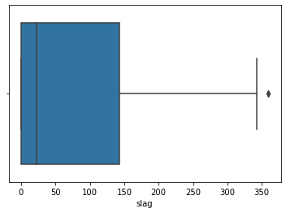

```python
cutoff_slag = 1.5 * iqr_slag
low_lim_slag = slag_25 - cutoff_slag
upp_lim_slag = slag_75 + cutoff_slag

outlier_slag = [x for x in concrete_data['slag'] if x < low_lim_slag or x > upp_lim_slag]
print("The number of outliers in 'slag' out off 1030 records are:", len(outlier_slag))

#plotting of 'slag':
sns.boxplot(concrete_data['slag'])
```

##### - Data Distribution in Slag

```
The skewness in the data is: 0.8007168956061774
```

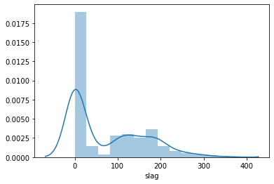

```python
sns.distplot(concrete_data['slag'], kde = True)
print("The skewness in the data is:", concrete_data['slag'].skew())
```

###### - Missing Values in Slag

```python
print("The number of missing values in slag is:", concrete_data['slag'].isnull().sum())
```

```
The number of missing values in slag is: 0
```

### Ash

##### - Range of values observed

```python
print("The value for ash ranges from", concrete_data['ash'].min() , "to", concrete_data['ash'].max(), "thus having a range of", (concrete_data['ash'].max() - concrete_data['ash'].min()) )
```

```
The value for ash ranges from 0.0 to 200.1 thus having a range of 200.1
```

##### - Central Values

```python
print("Mean of the values in ash is:", round(concrete_data['ash'].mean(), 2))
print("Median of the values in ash is:", round(concrete_data['ash'].median(), 2))
```

```
Mean of the values in ash is: 54.19
Median of the values in ash is: 0.0
```

##### - Standard Deviation

```python
print("The observations in ash deviates from mean by:", round(concrete_data['ash'].std(), 2))
```

```
The observations in ash deviates from mean by: 64.0
```

##### - Quartiles

```python
ash_25 = np.percentile(concrete_data['ash'], 25)
ash_75 = np.percentile(concrete_data['ash'], 75)
iqr_ash = ash_75 - ash_25

print("The first quartile Q1 is:", ash_25)
print("The third quartile Q3 is:", ash_75)
print("The interquartile range IQR is:", iqr_ash)
```

```
The first quartile Q1 is: 0.0
The third quartile Q3 is: 118.3
The interquartile range IQR is: 118.3
```

##### - Outliers Detection

```
The number of outliers in 'ash' out off 1030 records are: 0
```

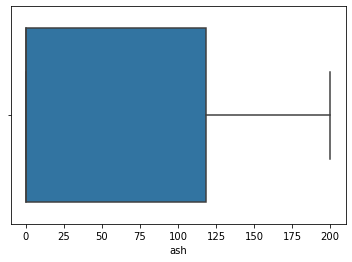

```python
cutoff_ash = 1.5 * iqr_ash
low_lim_ash = ash_25 - cutoff_ash
upp_lim_ash = ash_75 + cutoff_ash

outlier_ash = [x for x in concrete_data['ash'] if x < low_lim_ash or x > upp_lim_ash]
print("The number of outliers in 'ash' out off 1030 records are:", len(outlier_ash))

#plotting of 'ash':
sns.boxplot(concrete_data['ash'])
```

```
The skewness in the data is: 0.5373539058066844
```

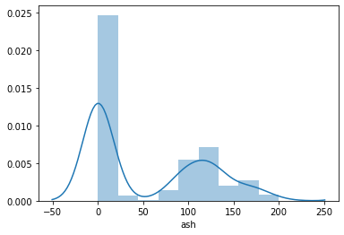

```python
sns.distplot(concrete_data['ash'], kde = True)
print("The skewness in the data is:", concrete_data['ash'].skew())
```

###### - Missing Values in Ash

```python
print("The number of missing values in ash is:", concrete_data['ash'].isnull().sum())
```

```
The number of missing values in ash is: 0
```

### Water

##### - Range of values observed

```python
print("The value for water ranges from", concrete_data['water'].min() , "to", concrete_data['water'].max(), "thus having a range of", (concrete_data['water'].max() - concrete_data['water'].min()) )
```

```
The value for water ranges from 121.8 to 247.0 thus having a range of 125.2
```

##### - Central Values

```python
print("Mean of the values in water is:", round(concrete_data['water'].mean(), 2))
print("Median of the values in water is:", round(concrete_data['water'].median(), 2))
```

```
Mean of the values in water is: 181.57
Median of the values in water is: 185.0
```

##### - Standard Deviation

```python
print("The observations in water deviates from mean by:", round(concrete_data['water'].std(), 2))
```

```
The observations in water deviates from mean by: 21.35
```

##### - Quartiles

```python
water_25 = np.percentile(concrete_data['water'], 25)
water_75 = np.percentile(concrete_data['water'], 75)
iqr_water = water_75 - water_25

print("The first quartile Q1 is:", water_25)
print("The third quartile Q3 is:", water_75)
print("The interquartile range IQR is:", iqr_water)
```

```
The first quartile Q1 is: 164.9
The third quartile Q3 is: 192.0
The interquartile range IQR is: 27.099999999999994
```

##### - Outliers Detection

```
The number of outliers in 'water' out off 1030 records are: 9
```

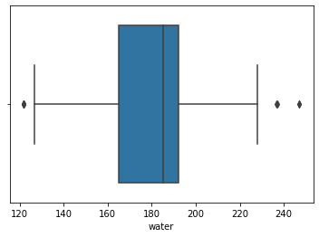

```python
cutoff_water = 1.5 * iqr_water
low_lim_water = water_25 - cutoff_water
upp_lim_water = water_75 + cutoff_water

outlier_water = [x for x in concrete_data['water'] if x < low_lim_water or x > upp_lim_water]
print("The number of outliers in 'water' out off 1030 records are:", len(outlier_water))

#plotting of 'water':
sns.boxplot(concrete_data['water'])
```

##### - Data Distribution in Water

```
The skewness in the data is: 0.07462838428549402
```

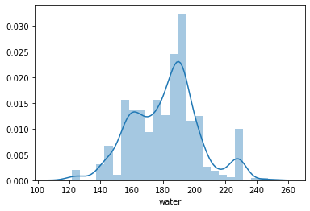

```python
sns.distplot(concrete_data['water'], kde = True)
print("The skewness in the data is:", concrete_data['water'].skew())
```

###### - Missing Values in Water

```python
print("The number of missing values in water is:", concrete_data['water'].isnull().sum())
```

```
The number of missing values in water is: 0
```

### Superplastic

##### - Range of values observed

```python
print("The value for superplastic ranges from", concrete_data['superplastic'].min() , "to", concrete_data['superplastic'].max(), "thus having a range of", (concrete_data['superplastic'].max() - concrete_data['superplastic'].min()) )
```

```
The value for superplastic ranges from 0.0 to 32.2 thus having a range of 32.2
```

##### - Central Values

```python
print("Mean of the values in superplastic is:", round(concrete_data['superplastic'].mean(), 2))
print("Median of the values in superplastic is:", round(concrete_data['superplastic'].median(), 2))
```

```
Mean of the values in superplastic is: 6.2
Median of the values in superplastic is: 6.4
```

##### - Standard Deviation

```python
print("The observations in superplastic deviates from mean by:", round(concrete_data['superplastic'].std(), 2))
```

```
The observations in superplastic deviates from mean by: 5.97
```

##### - Quartiles

```python
superplastic_25 = np.percentile(concrete_data['superplastic'], 25)
superplastic_75 = np.percentile(concrete_data['superplastic'], 75)
iqr_superplastic = superplastic_75 - superplastic_25

print("The first quartile Q1 is:", superplastic_25)
print("The third quartile Q3 is:", superplastic_75)
print("The interquartile range IQR is:", iqr_superplastic)
```

```
The first quartile Q1 is: 0.0
The third quartile Q3 is: 10.2
The interquartile range IQR is: 10.2
```

##### - Outliers Detection

```
The number of outliers in 'superplastic' out off 1030 records are: 10
```

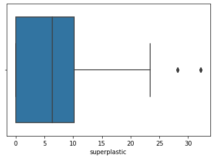

```python
cutoff_superplastic = 1.5 * iqr_superplastic
low_lim_superplastic = superplastic_25 - cutoff_superplastic
upp_lim_superplastic = superplastic_75 + cutoff_superplastic

outlier_superplastic = [x for x in concrete_data['superplastic'] if x < low_lim_superplastic or x > upp_lim_superplastic]
print("The number of outliers in 'superplastic' out off 1030 records are:", len(outlier_superplastic))

#plotting of 'superplastic':
sns.boxplot(concrete_data['superplastic'])
```

##### - Data Distribution in Superplastic

```
The skewness in the data is: 0.9072025748672466
```

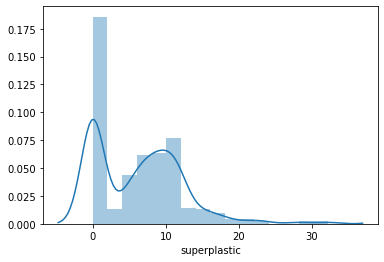

```python
sns.distplot(concrete_data['superplastic'], kde = True)
print("The skewness in the data is:", concrete_data['superplastic'].skew())
```

###### - Missing Values in Superplastic

```python
print("The number of missing values in superplastic is:", concrete_data['superplastic'].isnull().sum())
```

```
The number of missing values in superplastic is: 0
```

### Coarseagg

##### - Range of values observed

```python
print("The value for coarseagg ranges from", concrete_data['coarseagg'].min() , "to", concrete_data['coarseagg'].max(), "thus having a range of", (concrete_data['coarseagg'].max() - concrete_data['coarseagg'].min()) )
```

```
The value for coarseagg ranges from 801.0 to 1145.0 thus having a range of 344.0
```

##### - Central Values

```python
print("Mean of the values in coarseagg is:", round(concrete_data['coarseagg'].mean(), 2))
print("Median of the values in coarseagg is:", round(concrete_data['coarseagg'].median(), 2))
```

```
Mean of the values in coarseagg is: 972.92
Median of the values in coarseagg is: 968.0
```

##### - Standard Deviation

```python
print("The observations in coarseagg deviates from mean by:", round(concrete_data['coarseagg'].std(), 2))
```

```
The observations in coarseagg deviates from mean by: 77.75
```

##### - Quartiles

```python
coarseagg_25 = np.percentile(concrete_data['coarseagg'], 25)
coarseagg_75 = np.percentile(concrete_data['coarseagg'], 75)
iqr_coarseagg = coarseagg_75 - coarseagg_25

print("The first quartile Q1 is:", coarseagg_25)
print("The third quartile Q3 is:", coarseagg_75)
print("The interquartile range IQR is:", iqr_coarseagg)
```

```
The first quartile Q1 is: 932.0
The third quartile Q3 is: 1029.4
The interquartile range IQR is: 97.40000000000009
```

##### - Outliers Detection

```
The number of outliers in 'coarseagg' out off 1030 records are: 0
```

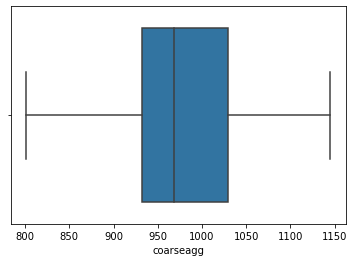

```python
cutoff_coarseagg = 1.5 * iqr_coarseagg
low_lim_coarseagg = coarseagg_25 - cutoff_coarseagg
upp_lim_coarseagg = coarseagg_75 + cutoff_coarseagg

outlier_coarseagg = [x for x in concrete_data['coarseagg'] if x < low_lim_coarseagg or x > upp_lim_coarseagg]
print("The number of outliers in 'coarseagg' out off 1030 records are:", len(outlier_coarseagg))

#plotting of 'coarseagg':
sns.boxplot(concrete_data['coarseagg'])
```

##### - Data Distribution in Coarseagg

```
The skewness in the data is: -0.04021974481106704
```

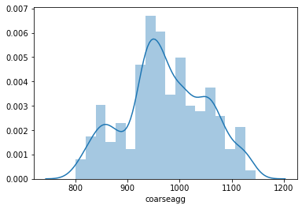

```python
sns.distplot(concrete_data['coarseagg'], kde = True)
print("The skewness in the data is:", concrete_data['coarseagg'].skew())
```

##### - Missing Values in Coarseagg

```python
print("The number of missing values in coarseagg is:", concrete_data['coarseagg'].isnull().sum())
```

```
The number of missing values in coarseagg is: 0
```

### Fineagg

##### - Range of values observed

```python
print("The value for fineagg ranges from", concrete_data['fineagg'].min() , "to", concrete_data['fineagg'].max(), "thus having a range of", (concrete_data['fineagg'].max() - concrete_data['fineagg'].min()) )
```

```
The value for fineagg ranges from 594.0 to 992.6 thus having a range of 398.6
```

##### - Central Values

```python
print("Mean of the values in fineagg is:", round(concrete_data['fineagg'].mean(), 2))
print("Median of the values in fineagg is:", round(concrete_data['fineagg'].median(), 2))
```

```
Mean of the values in fineagg is: 773.58
Median of the values in fineagg is: 779.5
```

##### - Standard Deviation

```python
print("The observations in fineagg deviates from mean by:", round(concrete_data['fineagg'].std(), 2))
```

```
The observations in fineagg deviates from mean by: 80.18
```

##### - Quartiles

```python
fineagg_25 = np.percentile(concrete_data['fineagg'], 25)
fineagg_75 = np.percentile(concrete_data['fineagg'], 75)
iqr_fineagg = fineagg_75 - fineagg_25

print("The first quartile Q1 is:", fineagg_25)
print("The third quartile Q3 is:", fineagg_75)
print("The interquartile range IQR is:", iqr_fineagg)
```

```
The first quartile Q1 is: 730.9499999999999
The third quartile Q3 is: 824.0
The interquartile range IQR is: 93.05000000000007
```

##### - Outliers Detection

```
The number of outliers in 'fineagg' out off 1030 records are: 5
```

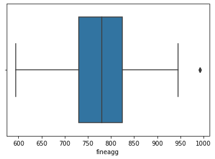

```python
cutoff_fineagg = 1.5 * iqr_fineagg
low_lim_fineagg = fineagg_25 - cutoff_fineagg
upp_lim_fineagg = fineagg_75 + cutoff_fineagg

outlier_fineagg = [x for x in concrete_data['fineagg'] if x < low_lim_fineagg or x > upp_lim_fineagg]
print("The number of outliers in 'fineagg' out off 1030 records are:", len(outlier_fineagg))

#plotting of 'fineagg':
sns.boxplot(concrete_data['fineagg'])
```

##### - Data Distribution in Fineagg

```
The skewness in the data is: -0.25300959769707143
```

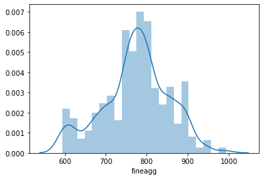

```python
sns.distplot(concrete_data['fineagg'], kde = True)
print("The skewness in the data is:", concrete_data['fineagg'].skew())
```

```python
print("The number of missing values in fineagg is:", concrete_data['fineagg'].isnull().sum())
```

```
The number of missing values in fineagg is: 0
```

### Age

```python
concrete_data['age'].value_counts()
```

```
28     425
3      134
7      126
56      91
14      62
90      54
100     52
180     26
91      22
365     14
270     13
360      6
120      3
1        2
Name: age, dtype: int64
```

So, the 1030 observations has been taken across 14 different age.

##### - Range of values observed

```python
print("The value for age ranges from", concrete_data['age'].min() , "to", concrete_data['age'].max(), "thus having a range of", (concrete_data['age'].max() - concrete_data['age'].min()) )
```

```
The value for age ranges from 1 to 365 thus having a range of 364
```

##### - Central Values

```python
print("Mean of the values in age is:", round(concrete_data['age'].mean(), 2))
print("Median of the values in age is:", round(concrete_data['age'].median(), 2))
```

```
Mean of the values in age is: 45.66
Median of the values in age is: 28.0
```

##### - Standard Deviation

```python
print("The observations in age deviates from mean by:", round(concrete_data['age'].std(), 2))
```

```
The observations in age deviates from mean by: 63.17
```

##### - Quartiles

```python
age_25 = np.percentile(concrete_data['age'], 25)
age_75 = np.percentile(concrete_data['age'], 75)
iqr_age = age_75 - age_25

print("The first quartile Q1 is:", age_25)
print("The third quartile Q3 is:", age_75)
print("The interquartile range IQR is:", iqr_age)
```

```
The first quartile Q1 is: 7.0
The third quartile Q3 is: 56.0
The interquartile range IQR is: 49.0
```

##### - Outliers Detection

```
The number of outliers in 'age' out off 1030 records are: 59
```

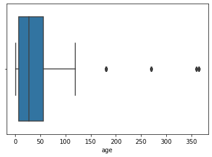

```python
cutoff_age = 1.5 * iqr_age
low_lim_age = age_25 - cutoff_age
upp_lim_age = age_75 + cutoff_age

outlier_age = [x for x in concrete_data['age'] if x < low_lim_age or x > upp_lim_age]
print("The number of outliers in 'age' out off 1030 records are:", len(outlier_age))

#plotting of 'age':
sns.boxplot(concrete_data['age'])
```

##### - Data Distribution in Age

```
The skewness in the data is: 3.2691774006345895
```

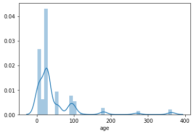

```python
sns.distplot(concrete_data['age'], kde = True)

print("The skewness in the data is:", concrete_data['age'].skew())
```

###### - Missing Values in Age

```python
print("The number of missing values in age is:", concrete_data['age'].isnull().sum())
```

```
The number of missing values in age is: 0
```

### Bivariate Analysis

##### - Relationship between Cement and Every other Predictors

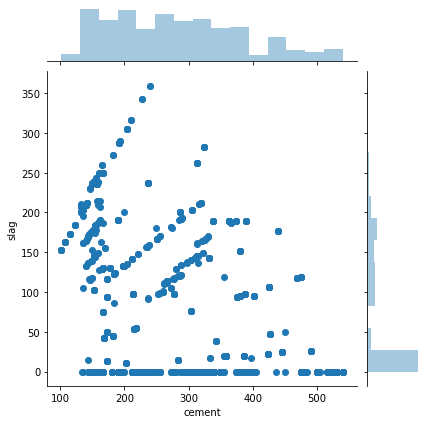

```python
# plotting between 'Cement' and 'Slag':
sns.jointplot(concrete_data['cement'], concrete_data['slag'])
```

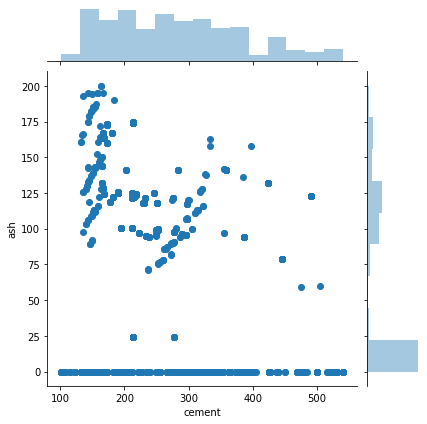

```python
# plotting between 'cement' and 'ash':
sns.jointplot(concrete_data['cement'], concrete_data['ash'])
```

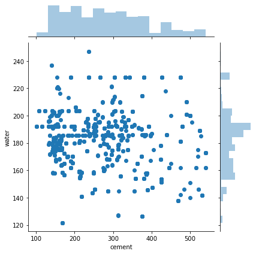

```python
# plotting between 'cement' and 'water':
sns.jointplot(concrete_data['cement'], concrete_data['water'])
```

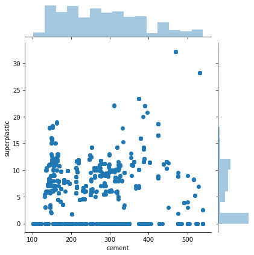

```python
# plotting between 'cement' and 'superplastic':
sns.jointplot(concrete_data['cement'], concrete_data['superplastic'])
```

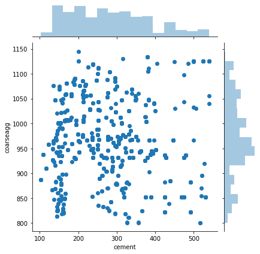

```python
# plotting between 'cement' and 'coarseagg':
sns.jointplot(concrete_data['cement'], concrete_data['coarseagg'])
```

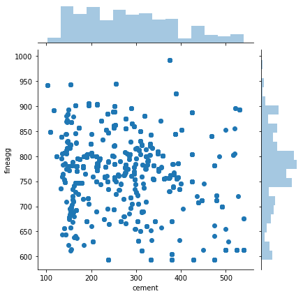

```python
# plotting between 'cement' and 'fineagg':
sns.jointplot(concrete_data['cement'], concrete_data['fineagg'])
```

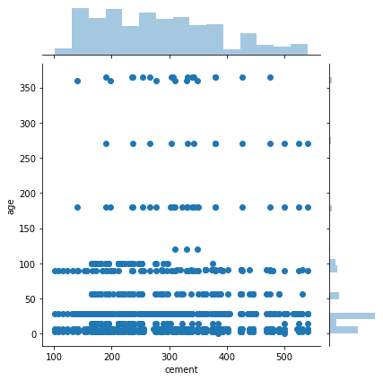

```python
# plotting between 'cement' and 'age':
sns.jointplot(concrete_data['cement'], concrete_data['age'])
```

##### - Relationship between Slag and Every other Predictors apart from Cement

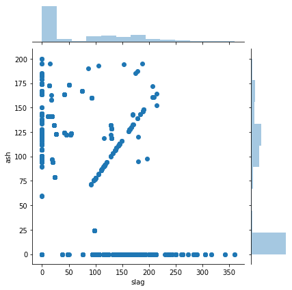

```python
sns.jointplot(concrete_data['slag'], concrete_data['ash'])
```

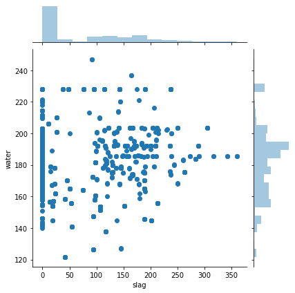

```python
sns.jointplot(concrete_data['slag'], concrete_data['water'])
```

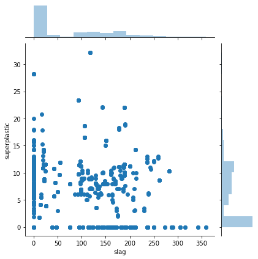

```python
# plotting 'slag' and 'superplastic':
sns.jointplot(concrete_data['slag'], concrete_data['superplastic'])
```

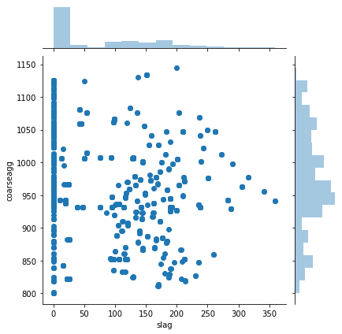

```python
# plotting betwen 'slag' and 'coarseagg':
sns.jointplot(concrete_data['slag'], concrete_data['coarseagg'])
```

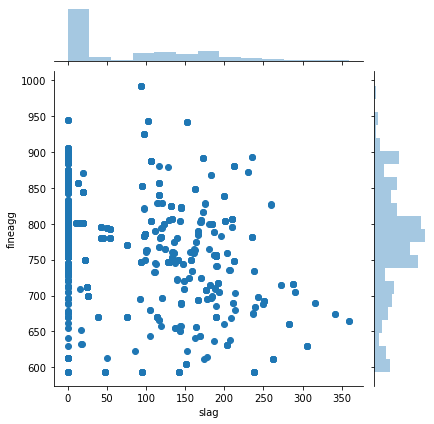

```python
# plotting between 'slag' and 'fineagg':
sns.jointplot(concrete_data['slag'], concrete_data['fineagg'])
```

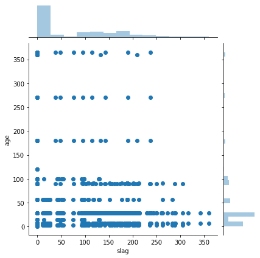

```python
# plotting between 'slag' and 'age':
sns.jointplot(concrete_data['slag'], concrete_data['age'])
```